# ClimDist_TigerMtn

Elizabeth R. Milano

2023-06-29

## Climate Distance mapper - Tiger Mountain example

**Purpose:** Climate Distance algorithm for current and future analogs. **Background:** Climate Distance project aims to identify contemporary climate analog locations for future climate scenarios at focal points of interest based on derived climate variables, plant survey data, and biotic community classifications (hereafter biomes). This document identifies analogs for the Tiger Mountain target location using the Forest Inventory and Analysis dataset, and Brown’s biomes.

**Data:**

- Background point dataset: This is used to define analog thresholds and determine `mean` and `sd` of derived climate variables for standardization purposes. The dataset is comprised of 988 lat/long locations, each point was then sampled along an artificial elevation cline to create a set of 50,388 observations. This analysis was done in a previous script and does not change across reference databases.
- Reference point dataset: For each inventory database (FIA, biome, ect.), contemporary climate data was pulled from `https://charcoal2.cnre.vt.edu//climate/customData/` for all lat/long occurrences. Biome classification can be found at `http://www.peter.unmack.net/biotic/`. FIA data https://apps.fs.usda.gov/fia/datamart/datamart.html. Data accessed Nov. 2022.
- Target dataset: Contains 13 future climate projections and contemporary data from source above for Tiger Mountain. *Note: This script is set up to loop through a list of target locations and create separate output files for each, however we will only focus on a single location for sake of example*

**Results files:** Text files contain list of analogs for each location and climate scenario, data for each analog includes lat/long, Edist (climate distance), km (geographic distance from focal location), and either species occurrence information or biome classification. Summary tables follow results output. Species comparisons and maps are generated in separate script.

```r
setwd("/Users/elizabethmilano/Library/CloudStorage/Box-Box/01. elizabeth.milano Workspace/ClimDist/github/scripts")
rm(list=ls())

library(yaImpute) # nearest neighbor
library(gower)
library(geosphere) # calculate km distance between geo points
library(tidyverse) # tidy data
```

## Load data

### Background data stats

Used for standardization and thresholds.

```r
stats <- read.csv("../data/ClimDist_stats.csv")
```

### Reference data

#### Current climate

Reference dataset is a combined set of points from FIA and biome data. A new PointID index was generated for the biome and FIA points by starting the count at 30,000 and 500,000 to avoid duplication with the AIM dataset (not used for Tiger Mountain).

```r
# Current climate for reference points
#aim.data <- read.table("../data/AIM_currentClim_derived.txt",header=T,sep="",na.strings=".") %>%
#  rename(mindd0 = mmindd0) %>%
#  select(-smrsprpb, -smrpb) %>%
#  mutate(zone = NA,
#         PointID_biome = NA,
#         PointID_fia = NA)

biome.tmp <- read.table("../data/BRupdate.txt",header=T,sep="",na.strings=".") %>%
  rename(PointID_biome = PointID,
         smrp = sump)
n_row.b <- nrow(biome.tmp)
biome.data <- biome.tmp %>%
  mutate(PointID = seq(30001,(30000+n_row.b)), #index accounts for AIM dataset, if using.
         PointID_fia = NA)


fia.tmp1 <- read.table("../data/FIA_08.24.15.txt",header=T,sep="",na.strings=".") %>%
  rename(PointID_fia = newid,
         smrp = sump)
n_row.f <- nrow(fia.tmp1)
fia.tmp2 <- fia.tmp1 %>%
  mutate(PointID = seq(500001,(500000+n_row.f)), #index accounts for AIM and biome datasets, if using.
         PointID_biome = NA,
         zone = NA)
fia.data <- fia.tmp2 %>%
  select(PointID, long, lat, elev, mat, map, gsp, dd5, dd0, gsdd5, mtcm, mmin, mtwm, mmax, sday, fday, ffp, d100, mindd0, winp, smrp, sprp,
         PointID_biome, zone, PointID_fia)

ref.data <- rbind(#aim.data,
                  biome.data,
                  fia.data) %>%
  select(-PointID_biome, -PointID_fia)
```

#### Vegetation and biomes

```r
# Vegetation
#aim.species <- read.table("../data/BLMfull_withnox.csv",header=T,sep=",",na.strings="NA")

#biome
biome <- biome.data %>%
  select(PointID, PointID_biome, zone)
biome.code <- read.delim("../data/Brown_biome_code.txt")

#FIA
fia.species <- fia.tmp2 %>%
  select(-mat, -map, -gsp, -dd5, -dd0, -gsdd5, -mtcm, -mmin, -mtwm, -mmax, -sday, -fday, -ffp, -d100, -mindd0, -winp, -smrp, -sprp,
         -PointID_biome, -zone, -long, -lat, -elev, -PIGL.1)
# FIA species
fia.species.lookup <- read.csv("../data/FIA_master_list.csv", na.strings = "NA") %>%
  unite("latin", Genus, Species, Subspecies, Variety, na.rm = TRUE, remove = FALSE) %>%
  rename(species_code = PLANTS_Code)
```

### Target data

#### Future climate

Pull `*_y2060_derived.txt` files from `https://charcoal2.cnre.vt.edu//climate/customData/`.

```r
# Target points
target.future.files <- list.files(path="../data/charcoal",full.names=TRUE, pattern = "y2060_derived.txt$")

# list futures
future.table <- data.frame(Filepath = target.future.files) %>%
  separate(col = Filepath, sep = "/", into = c(NA, NA, NA, "File")) %>%
  separate(col = File, sep = "_", into = c("Model", "Scenario", "Year"), remove = FALSE)

target.future.data <- read_delim(target.future.files, col_names = TRUE, delim=" ", na=".", show_col_types = FALSE) %>%
  bind_rows() %>%
  group_by(PointID) %>%
  summarise_all(mean)%>%
  rename(mindd0 = mmindd0)
write.csv(target.future.data, "../output/future/future_climate_target.csv", row.names = FALSE)


# list focal points
fp.table <- target.future.data %>%
  select(PointID, long, lat, elev) %>%
  rename("Longitude W" = "long",
         "Latitude N" = "lat",
         "Elevation m" = "elev")
```

#### Contemporary climate

```r
target.current.data <- read.table("../data/charcoal/currentClim_derived.txt",header=T,sep="",na.strings=".") %>%

  rename(mindd0 = mmindd0)
write.csv(target.current.data, "../output/current/current_climate_target.csv", row.names = FALSE)
```

#### Target data summary

Table 1. Future climate scenarios.

| File | Model | Scenario | Year |
| --- | --- | --- | --- |
| CCSM4_rcp45_y2060_derived.txt | CCSM4 | rcp45 | y2060 |
| CCSM4_rcp60_y2060_derived.txt | CCSM4 | rcp60 | y2060 |
| CCSM4_rcp85_y2060_derived.txt | CCSM4 | rcp85 | y2060 |
| CESM1BGC_rcp45_y2060_derived.txt | CESM1BGC | rcp45 | y2060 |
| CESM1BGC_rcp85_y2060_derived.txt | CESM1BGC | rcp85 | y2060 |
| CNRMCM5_rcp45_y2060_derived.txt | CNRMCM5 | rcp45 | y2060 |
| CNRMCM5_rcp85_y2060_derived.txt | CNRMCM5 | rcp85 | y2060 |
| GFDLCM3_rcp45_y2060_derived.txt | GFDLCM3 | rcp45 | y2060 |
| GFDLCM3_rcp60_y2060_derived.txt | GFDLCM3 | rcp60 | y2060 |
| GFDLCM3_rcp85_y2060_derived.txt | GFDLCM3 | rcp85 | y2060 |
| HadGEM2ES_rcp45_y2060_derived.txt | HadGEM2ES | rcp45 | y2060 |
| HadGEM2ES_rcp60_y2060_derived.txt | HadGEM2ES | rcp60 | y2060 |
| HadGEM2ES_rcp85_y2060_derived.txt | HadGEM2ES | rcp85 | y2060 |

Table 2. Target point location(s).

| PointID | Longitude W | Latitude N | Elevation m |
| --- | --- | --- | --- |
| TigerMtn | -122.0345 | 47.5297 | 200 |

## Functions

1. Create derived climate variables

Climate variable definitions:  
All temperature is in degrees C and precipitation in mm.

Derived variables:  
**tdiff** = Mean temp warmest month minus coldest month, `mtwm - mtcm`.  
**pratio** = Ratio of summer precipitation to total precipitation, `gsp / map`.  
**adi** = Annual dryness index, `sqrt(dd5)/map`.  
**sdi** = Summer dryness index, `sqrt(gsdd5)/gsp`.  
**adimindd0** = `adi * (mindd0 + 1)`  
**sdimindd0** = `(sqrt(gsdd5) / gsp) * (mindd0 + 1))`  
**mapdd5** = `(map * dd5) / 1000`  
**gspdd5** = `(gsp * dd5) / 1000`  
**smratio** = `smrp/gsp`

```r
der.vars <- function(df) {
  output <- df %>%
    mutate(tdiff = mtwm - mtcm,
           pratio = gsp / map,
           adi = (dd5 ** 0.5) / map,
           sdi = (gsdd5 ** 0.5) / gsp,
           mapdd5 = (map * dd5) / 1000,
           gspdd5 = (gsp * dd5) / 1000,
           adimindd0 = adi * (mindd0 + 1),
           sdimindd0 = ((gsdd5 ** 0.5) / gsp) * (mindd0 + 1),
           smratio = smrp/gsp)
  return(output)
}
```

2. Standardize new variables with `stats` dataset

```r
# Standardize vars with "stats"
std.stats <- function(df){
  output <- df %>%
    dplyr::mutate(dd5 = (dd5 - stats$Xdd5) / stats$Sdd5,
           mat = (mat - stats$Xmat) / stats$Smat,
           d100 = (d100 - stats$Xd100) / stats$Sd100,
           map = (map - stats$Xmap) / stats$Smap,
           gsp = (gsp - stats$Xgsp) / stats$Sgsp,
           winp = (winp - stats$Xwinp) / stats$Swinp,
           mmax = (mmax - stats$Xmmax) / stats$Smmax,
           tdiff = (tdiff - stats$Xtdiff) / stats$Stdiff,
           pratio = (pratio - stats$Xpratio) / stats$Spratio,
           adi = (adi - stats$Xadi) / stats$Sadi,
           sdi = (sdi - stats$Xsdi) / stats$Ssdi,
           adimindd0 = (adimindd0 - stats$Xadimindd0) / stats$Sadimindd0,
           sdimindd0 = (sdimindd0 - stats$Xsdimindd0) / stats$Ssdimindd0,
           mtcm = (mtcm - stats$Xmtcm) / stats$Smtcm,
           mapdd5 = (mapdd5 - stats$Xmapdd5) / stats$Smapdd5,
           gspdd5 = (gspdd5 - stats$Xgspdd5) / stats$Sgspdd5,
           smrp = (smrp - stats$Xsmrp)/stats$Ssmrp,
           sprp = (sprp -stats$Xsprp)/stats$Ssprp,
           smratio = (smratio - stats$Xsmratio)/stats$Ssmratio
          ) %>%
    select(PointID, long, lat, elev, dd5, mat, d100, map, gsp, winp, mmax, tdiff, pratio, adi, sdi, adimindd0, sdimindd0, mtcm, mapdd5, gspdd5, smrp, sprp, smratio)
  return(output)
}
```

## Data Transformation

Apply functions above to prepare files.

```r
# reference data
ref.vars <- der.vars(ref.data)
ref <- std.stats(ref.vars)

# target future data
target.future.vars <- der.vars(target.future.data)
target.future <- std.stats(target.future.vars)

# target current data
target.current.vars <- der.vars(target.current.data)
target.current <- std.stats(target.current.vars)
```

## Find future climate analogs

```r
#aim.future <- list()
biome.future <- list()
fia.future <- list()
#clim.future <- list()

 for (irow in 1:nrow(target.future))
 {

 trg <- target.future[irow,]

 # set focal point lat/long
 trg.long <- trg$long
 trg.lat <- trg$lat
 trg.elev <- trg$elev

 # yai format needs rownames
 rownames(ref) = paste("R",sprintf(fmt="%4.4d",1:nrow(ref)),sep="")
 rownames(trg) = paste("",sprintf(fmt="%4.4d",1:nrow(trg)),sep="")

 # yaImpute
 yai = yai (x=ref[,5:ncol(ref)],method="raw",noRefs=TRUE,k=2500)
 yai2 = newtargets(yai,newdata=trg)

 # pull results
 ids = yai2$neiIdsTrg[,1:2500] # identifies R_number from ref
 dsts = round(yai2$neiDstTrg[,1:2500],2)

  # format output
#   aim.future[[trg$PointID]] <- data.frame(Edist=dsts, id=ids) %>%
#     filter(Edist <= 1.75) %>%
#     left_join(ref %>% rownames_to_column("rowname"), by=c("id"="rowname")) %>% # join by 'R' rowname of ref
#     select(PointID, long, lat, elev, Edist) %>%
#     mutate(Edist_thresh = case_when(
#      Edist <= 0.6 ~ "strong",
#      Edist > 0.6 & Edist <= 0.72 ~ "moderate",
#      Edist > 0.72 & Edist <= 0.84 ~ "weak",
#      Edist > 0.84 ~ "under_thresh",
#      TRUE ~ "NA")) %>%
#     rowwise() %>% # needed for km calculation
#     mutate(elev_diff = trg.elev - elev,
#            km = (distm(c(trg.long, trg.lat), c(long,lat), fun = distGeo)/1000)[1]) %>% # km distance between focal and analog lat/long
#     left_join(aim.species) %>%
#     drop_na() %>%
#     select_if(~ !is.numeric(.) || sum(.) != 0) # remove species columns without info
#
#    write.table (aim.future[[trg$PointID]], paste0("../output/future/","future_analog_", trg$PointID, "_AIM.txt"),row.names=FALSE)

    biome.future[[trg$PointID]] <- data.frame(Edist=dsts, id=ids) %>%
      filter(Edist <= 1.75) %>%
      left_join(ref %>% rownames_to_column("rowname"), by=c("id"="rowname")) %>% # join by 'R' rowname of ref
      select(PointID, long, lat, elev, Edist) %>%
      mutate(Edist_thresh = case_when(
      Edist <= 0.6 ~ "strong",
      Edist > 0.6 & Edist <= 0.72 ~ "moderate",
      Edist > 0.72 & Edist <= 0.84 ~ "weak",
      Edist > 0.84 ~ "under_thresh",
        TRUE ~ "NA")) %>%
      rowwise() %>% # needed for km calculation
      mutate(elev_diff = trg.elev - elev,
             km = (distm(c(trg.long, trg.lat), c(long,lat), fun = distGeo)/1000)[1]) %>% # km distance between focal and analog lat/long
      left_join(biome) %>%
    left_join(biome.code) %>%
    drop_na()

    write.table (biome.future[[trg$PointID]], paste0("../output/future/","future_analog_", trg$PointID, "_biome.txt"),row.names=FALSE)

    fia.future[[trg$PointID]] <- data.frame(Edist=dsts, id=ids) %>%
      filter(Edist <= 1.75) %>%
      left_join(ref %>% rownames_to_column("rowname"), by=c("id"="rowname")) %>% # join by 'R' rowname of ref
      select(PointID, long, lat, elev, Edist) %>%
      mutate(Edist_thresh = case_when(
      Edist <= 0.6 ~ "strong",
      Edist > 0.6 & Edist <= 0.72 ~ "moderate",
      Edist > 0.72 & Edist <= 0.84 ~ "weak",
      Edist > 0.84 ~ "under_thresh",
      TRUE ~ "NA")) %>%
      rowwise() %>% # needed for km calculation
      mutate(elev_diff = trg.elev - elev,
             km = (distm(c(trg.long, trg.lat), c(long,lat), fun = distGeo)/1000)[1]) %>% # km distance between focal and analog lat/long
      left_join(fia.species) %>%
      drop_na() %>%
      select_if(~ !is.numeric(.) || sum(.) != 0) # remove species columns without info

    write.table (fia.future[[trg$PointID]], paste0("../output/future/","future_analog_", trg$PointID, "_FIA.txt"),row.names=FALSE)

#    ## output climate vars for all analogs
#    clim.future[[trg$PointID]] <- data.frame(Edist=dsts, id=ids) %>%
#     filter(Edist <= 1.75) %>%
#     left_join(ref %>% rownames_to_column("rowname"), by=c("id"="rowname")) %>% # join by 'R' rowname of ref
##    select(PointID, long, lat, elev, Edist) %>%
#     mutate(Edist_thresh = case_when(
#      Edist <= 0.6 ~ "strong",
#      Edist > 0.6 & Edist <= 0.72 ~ "moderate",
#      Edist > 0.72 & Edist <= 0.84 ~ "weak",
#      Edist > 0.84 ~ "under_thresh",
#              TRUE ~ "NA"),
#      analog_dataset = case_when(
#       PointID <= 30000 ~ "AIM",
#       PointID > 30000 & PointID <= 500000 ~ "Biome",
#       PointID > 500000 ~ "FIA",
#       TRUE ~ "NA")) %>%
#     rowwise() %>% # needed for km calculation
#     mutate(elev_diff = trg.elev - elev,
#            km = (distm(c(trg.long, trg.lat), c(long,lat), fun = distGeo)/1000)[1]) %>% # km distance between focal and analog lat/long
#     drop_na()
#
#    write.table (clim.future[[trg$PointID]], paste0("../output/future/","future_analog_", trg$PointID, "_climate.txt"),row.names=FALSE)
}

#clim.future.df <-  bind_rows(clim.future, .id = "PlotID") %>%
#  filter(Edist < 0.9)
#write.csv(clim.future.df, "../output/future/future_GB_trans_climate.csv", row.names = FALSE)
```

Table 4. Example format for output file for future climate analogs with biome classification.

| PointID | long | lat | elev | Edist | Edist_thresh | elev_diff | km | PointID_biome | zone | biome_description |
| --- | --- | --- | --- | --- | --- | --- | --- | --- | --- | --- |
| 149659 | -122.30 | 45.53 | 6 | 0.57 | strong | 194 | 223.2209 | 480495 | 31 | Oregonian_Coastal_Conifer_Forest |
| 149660 | -122.26 | 45.53 | 65 | 0.71 | moderate | 135 | 222.9619 | 480496 | 31 | Oregonian_Coastal_Conifer_Forest |
| 149654 | -122.39 | 45.49 | 137 | 0.73 | weak | 63 | 228.3706 | 480461 | 31 | Oregonian_Coastal_Conifer_Forest |
| 149653 | -122.43 | 45.49 | 159 | 0.79 | weak | 41 | 228.7575 | 480460 | 31 | Oregonian_Coastal_Conifer_Forest |
| 149679 | -122.39 | 45.62 | 136 | 0.79 | weak | 64 | 214.0284 | 480564 | 31 | Oregonian_Coastal_Conifer_Forest |
| 149624 | -122.39 | 45.31 | 214 | 0.82 | weak | -14 | 248.2488 | 480346 | 31 | Oregonian_Coastal_Conifer_Forest |

Table 5. Example format for output file for future climate analogs with FIA species composition.

| PointID | long | lat | elev | Edist | Edist_thresh | elev_diff | km | PointID_fia | ABAM | ABCO | ABGR | ABPR | CHLA | CHNO | CADE27 | PISI | PIAT | PICO | PILA | PIMO3 | PIPO | PSME | SESE3 | TABR2 | THPL | TOCA | TSHE | TSME | POTR5 | … |
| --- | --- | --- | --- | --- | --- | --- | --- | --- | --- | --- | --- | --- | --- | --- | --- | --- | --- | --- | --- | --- | --- | --- | --- | --- | --- | --- | --- | --- | --- | --- |
| 582864 | -122.35 | 45.61 | 60 | 0.66 | moderate | 140 | 214.7644 | 82864 | 0 | 0 | 0 | 0 | 0 | 0 | 0 | 0 | 0 | 0 | 0 | 0 | 0 | 0 | 0 | 0 | 0 | 0 | 0 | 0 | 0 | … |
| 581358 | -122.31 | 45.33 | 122 | 0.67 | moderate | 78 | 245.4327 | 81358 | 0 | 0 | 0 | 0 | 0 | 0 | 0 | 0 | 0 | 0 | 0 | 0 | 0 | 0 | 0 | 0 | 0 | 0 | 0 | 0 | 0 | … |
| 581209 | -122.31 | 45.30 | 152 | 0.71 | moderate | 48 | 248.7551 | 81209 | 0 | 0 | 0 | 0 | 0 | 0 | 0 | 0 | 0 | 0 | 0 | 0 | 0 | 0 | 0 | 0 | 0 | 0 | 0 | 0 | 0 | … |
| 581680 | -122.32 | 45.39 | 152 | 0.73 | weak | 48 | 238.8582 | 81680 | 0 | 0 | 0 | 0 | 0 | 0 | 0 | 0 | 0 | 0 | 0 | 0 | 0 | 1 | 0 | 0 | 1 | 0 | 0 | 0 | 0 | … |
| 581885 | -122.35 | 45.43 | 152 | 0.74 | weak | 48 | 234.6575 | 81885 | 0 | 0 | 0 | 0 | 0 | 0 | 0 | 0 | 0 | 0 | 0 | 0 | 0 | 0 | 0 | 0 | 0 | 0 | 0 | 0 | 0 | … |
| 582251 | -122.41 | 45.50 | 122 | 0.74 | weak | 78 | 227.4562 | 82251 | 0 | 0 | 0 | 0 | 0 | 0 | 0 | 0 | 0 | 0 | 0 | 0 | 0 | 1 | 0 | 0 | 0 | 0 | 0 | 0 | 0 | … |

## Find current climate analogs

- Same process as future climate analogs except using the contemporary climate data as target dataset.
- Output files:  
  (+ AIM `/output/current/current_analog_[location]_AIM.txt`) *not used for Tiger Mtn*
  - Biome `/output/current/current_analog_[location]_biome.txt`
  - FIA `/output/current/current_analog_[location]_FIA.txt`

```r
#aim.current <- list()
biome.current <- list()
fia.current <- list()

 for (irow in 1:nrow(target.current))
 {

 trg <- target.current[irow,]

 # set focal point lat/long
 trg.long <- trg$long
 trg.lat <- trg$lat
 trg.elev <- trg$elev

 # yai format needs rownames
 rownames(ref) = paste("R",sprintf(fmt="%4.4d",1:nrow(ref)),sep="")
 rownames(trg) = paste("",sprintf(fmt="%4.4d",1:nrow(trg)),sep="")

 # yaImpute
 yai = yai (x=ref[,5:ncol(ref)],method="raw",noRefs=TRUE,k=2500)
 yai2 = newtargets(yai,newdata=trg)

 # pull results
 ids = yai2$neiIdsTrg[,1:2500] # identifies R_number from ref
 dsts = round(yai2$neiDstTrg[,1:2500],2)

  # format output
#   aim.current[[trg$PointID]] <- data.frame(Edist=dsts, id=ids) %>%
#     filter(Edist <= 1.75) %>%
#     left_join(ref %>% rownames_to_column("rowname"), by=c("id"="rowname")) %>% # join by 'R' rowname of ref
#     select(PointID, long, lat, elev, Edist) %>%
#     mutate(Edist_thresh = case_when(
#      Edist <= 0.6 ~ "strong",
#      Edist > 0.6 & Edist <= 0.72 ~ "moderate",
#      Edist > 0.72 & Edist <= 0.84 ~ "weak",
#      Edist > 0.84 ~ "under_thresh",
#       TRUE ~ "NA")) %>%
#     rowwise() %>% # needed for km calculation
#     mutate(elev_diff = trg.elev - elev,
#            km = (distm(c(trg.long, trg.lat), c(long,lat), fun = distGeo)/1000)[1]) %>% # km distance between focal and analog lat/long
#     left_join(aim.species) %>%
#     drop_na() %>%
#     select_if(~ !is.numeric(.) || sum(.) != 0) # remove species columns without info
#
#    write.table (aim.current[[trg$PointID]], paste0("../output/current/","current_analog_", trg$PointID, "_AIM.txt"),row.names=FALSE)


    biome.current[[trg$PointID]] <- data.frame(Edist=dsts, id=ids) %>%
      filter(Edist <= 1.75) %>%
      left_join(ref %>% rownames_to_column("rowname"), by=c("id"="rowname")) %>% # join by 'R' rowname of ref
      select(PointID, long, lat, elev, Edist) %>%
      mutate(Edist_thresh = case_when(
      Edist <= 0.6 ~ "strong",
      Edist > 0.6 & Edist <= 0.72 ~ "moderate",
      Edist > 0.72 & Edist <= 0.84 ~ "weak",
      Edist > 0.84 ~ "under_thresh",
        TRUE ~ "NA")) %>%
      rowwise() %>% # needed for km calculation
      mutate(elev_diff = trg.elev - elev,
             km = (distm(c(trg.long, trg.lat), c(long,lat), fun = distGeo)/1000)[1]) %>% # km distance between focal and analog lat/long
      left_join(biome) %>%
    left_join(biome.code) %>%
    drop_na()

    write.table (biome.current[[trg$PointID]], paste0("../output/current/","current_analog_", trg$PointID, "_biome.txt"),row.names=FALSE)

    fia.current[[trg$PointID]] <- data.frame(Edist=dsts, id=ids) %>%
      filter(Edist <= 1.75) %>%
      left_join(ref %>% rownames_to_column("rowname"), by=c("id"="rowname")) %>% # join by 'R' rowname of ref
      select(PointID, long, lat, elev, Edist) %>%
      mutate(Edist_thresh = case_when(
      Edist <= 0.6 ~ "strong",
      Edist > 0.6 & Edist <= 0.72 ~ "moderate",
      Edist > 0.72 & Edist <= 0.84 ~ "weak",
      Edist > 0.84 ~ "under_thresh",
    TRUE ~ "NA")) %>%
      rowwise() %>% # needed for km calculation
      mutate(elev_diff = trg.elev - elev,
             km = (distm(c(trg.long, trg.lat), c(long,lat), fun = distGeo)/1000)[1]) %>% # km distance between focal and analog lat/long
      left_join(fia.species) %>%
      drop_na() %>%
      select_if(~ !is.numeric(.) || sum(.) != 0) # remove species columns without info

    write.table (fia.current[[trg$PointID]], paste0("../output/current/","current_analog_", trg$PointID, "_FIA.txt"),row.names=FALSE)

}
```

## Analog summaries

*Code can be used for multiple target locations, here we will only look at Tiger Mountain FIA and biome results*.

### Biome dataset

Load results files.

```r
# Biome
current.b.files <- list.files(path="../output/current",full.names=TRUE, pattern = "_biome.txt")
current.b <- list()
for (file in current.b.files){
  name.tmp <- gsub(pattern = "../output/current/current_analog_", replacement = "", x = file)
  name <- gsub(pattern = "_biome.txt", replacement = "", x = name.tmp)
  current.b[[name]] <- read.delim(file = file, header=T, sep="", na.strings="NA") %>%
    mutate(scenario = "current",
           location = name)
}

future.b.files <- list.files(path="../output/future",full.names=TRUE, pattern = "_biome.txt")
future.b <- list()
for (file in future.b.files){
  name.tmp <- gsub(pattern = "../output/future/future_analog_", replacement = "", x = file)
  name <- gsub(pattern = "_biome.txt", replacement = "", x = name.tmp)
  future.b[[name]] <- read.delim(file = file, header=T, sep="", na.strings="NA") %>%
    mutate(scenario = "future",
           location = name)
}
```

Count analogs.

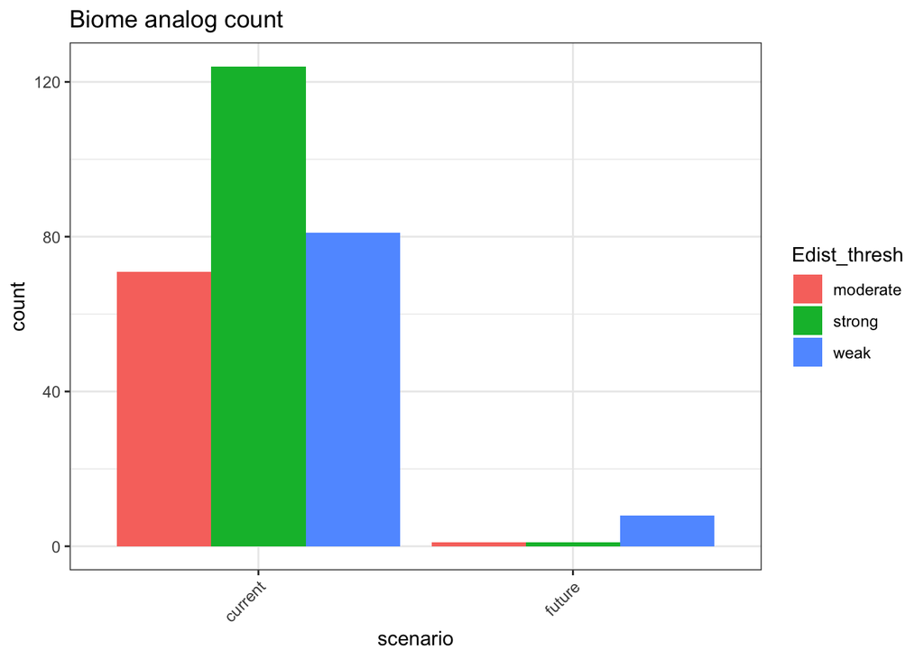

```r
## Current analogs
# remove empty elements from list
current.b <- current.b[map(current.b, ~dim(.)[1]) > 0]
# bind rows from list to dataframe
current.b.df <-  bind_rows(current.b, .id = "PlotID") %>%
  filter(Edist <= 0.84)

## Future analogs
# remove empty elements from list
future.b <- future.b[map(future.b, ~dim(.)[1]) > 0]
# bind rows from list to dataframe
future.b.df <-  bind_rows(future.b, .id = "PlotID") %>%
  filter(Edist <= 0.84)

b.plot <- current.b.df %>%
  bind_rows(future.b.df) %>%
  select(PlotID, scenario, Edist, Edist_thresh, elev, elev_diff, km)

b.bar <- ggplot(b.plot, aes(x=scenario, fill=Edist_thresh)) +
  geom_bar(position="dodge") +
  labs(title="Biome analog count") +
  theme_bw()+
  theme(axis.text.x = element_text(angle = 45, vjust = 1, hjust=1))
b.bar
```

Compare current and future.

```r
biome.sup.plots <- current.b.df %>%
  bind_rows(future.b.df) %>%
 # filter(PlotID %in% plots) %>%
  select(-PointID, -long, -lat, -Edist, -Edist_thresh, -elev, -elev_diff, -km, -PointID_biome) %>%
  group_by(scenario, PlotID, biome_description) %>% # if plots > 1, group by PlotID
  summarize(n=n()) %>%
  mutate(freq = n/sum(n)) %>%
  pivot_wider(id_cols =  "biome_description", names_from = c("PlotID","scenario"), values_from = "freq")
biome.sup.plots
```

```
## # A tibble: 4 × 3
##   biome_description                        TigerMtn_current TigerMtn_future
##   <chr>                                               <dbl>           <dbl>
## 1 Cascade-Sierran_Montane_Conifer_Forest             0.0652              NA
## 2 Cascade-Sierran_Subalpine_Conifer_Forest           0.0181              NA
## 3 Oregonian_Coastal_Conifer_Forest                   0.290                1
## 4 Sitka_Coastal_Conifer_Forest                       0.627               NA
```

```r
biome.sup.plots.stats <- current.b.df %>%
  bind_rows(future.b.df) %>%
#  filter(PlotID %in% plots) %>%
  select(scenario, elev, elev_diff, km, PlotID) %>%
  group_by(PlotID, scenario) %>%
  summarise(n_analog = n(),
            ave_elev_diff = mean(elev_diff),
            ave_km = mean(km))
biome.sup.plots.stats
```

```
## # A tibble: 2 × 5
## # Groups:   PlotID [1]
##   PlotID   scenario n_analog ave_elev_diff ave_km
##   <chr>    <chr>       <int>         <dbl>  <dbl>
## 1 TigerMtn current       276          105.   166.
## 2 TigerMtn future         10           68    232.
```

```r
write.csv(biome.sup.plots, file = "../output/biome_table.csv", row.names = FALSE)
write.csv(biome.sup.plots.stats, file = "../output/biome_analog_stats.csv", row.names = FALSE)
```

### FIA dataset

Load results files.

```r
current.f.files <- list.files(path="../output/current",full.names=TRUE, pattern = "_FIA.txt")
current.f <- list()
for (file in current.f.files){
  name.tmp <- gsub(pattern = "../output/current/current_analog_", replacement = "", x = file)
  name <- gsub(pattern = "_FIA.txt", replacement = "", x = name.tmp)
  current.f[[name]] <- read.delim(file = file, header=T, sep="", na.strings="NA") %>%
    mutate(scenario = "current",
           location = name)
}

future.f.files <- list.files(path="../output/future",full.names=TRUE, pattern = "_FIA.txt")
future.f <- list()
for (file in future.f.files){
  name.tmp <- gsub(pattern = "../output/future/future_analog_", replacement = "", x = file)
  name <- gsub(pattern = "_FIA.txt", replacement = "", x = name.tmp)
  future.f[[name]] <- read.delim(file = file, header=T, sep="", na.strings="NA") %>%
    mutate(scenario = "future",
           location = name)
}
```

Count analogs.

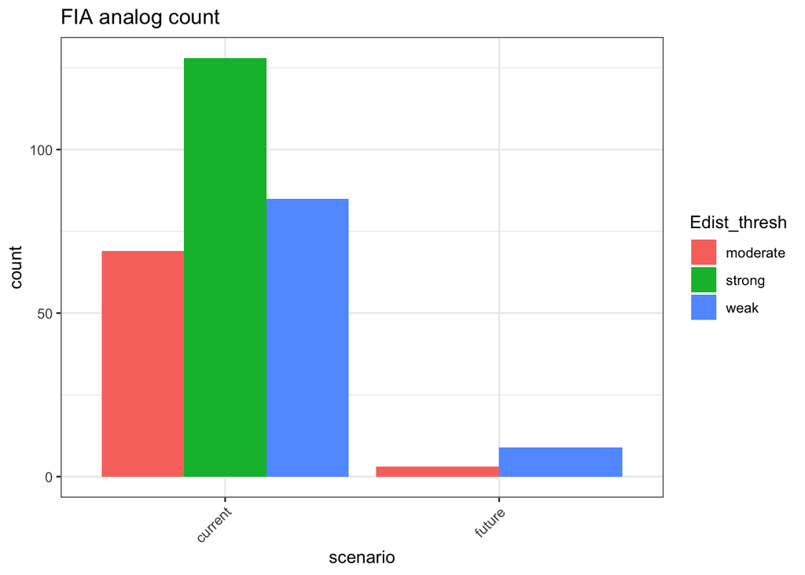

```r
## Current analogs
# remove empty elements from list
current.f <- current.f[map(current.f, ~dim(.)[1]) > 0]
# bind rows from list to dataframe
current.f.df <-  bind_rows(current.f, .id = "PlotID") %>%
  filter(Edist <= 0.84)
## Future analogs
# remove empty elements from list
future.f <- future.f[map(future.f, ~dim(.)[1]) > 0]
# bind rows from list to dataframe
future.f.df <-  bind_rows(future.f, .id = "PlotID") %>%
  filter(Edist <= 0.84)

f.plot <- current.f.df %>%
  bind_rows(future.f.df) %>%
  select(PlotID, scenario, Edist, Edist_thresh, elev, elev_diff, km)

f.bar <- ggplot(f.plot, aes(x=scenario, fill=Edist_thresh)) +
  geom_bar(position="dodge") +
  labs(title="FIA analog count") +
  theme_bw()+
  theme(axis.text.x = element_text(angle = 45, vjust = 1, hjust=1))
f.bar
```

Compare current and future analogs.

```r
fia.sup.plots <- current.f.df %>%
  bind_rows(future.f.df) %>%
  distinct() %>%
 # filter(PlotID %in% plots) %>%
  select(-PointID, -long, -lat, -Edist, -Edist_thresh, -elev, -elev_diff, -km, -PointID_fia) %>%
  replace(is.na(.), 0) %>%
  group_by(scenario) %>% # if plots > 1, group by PlotID
  summarise(n = n(),
            across(where(is.numeric), sum)) %>%
  mutate(across(where(is.numeric) & !n, ~.x/n)) %>%
  pivot_longer(cols = where(is.numeric) & !n, names_to = "species_code", values_to = "freq") %>%
  select(-n) %>%
  pivot_wider(names_from = c("scenario"), values_from = freq) %>%
  mutate(remove = case_when(if_all(starts_with("current"), ~.x < .05) & if_all(starts_with("future"), ~.x < .05) ~ "drop",
                           TRUE ~ "keep")) %>%
  filter(remove == "keep") %>%
  select(-remove) %>%
  # arrange(desc(current), .by_group = TRUE)  %>%
#  replace(is.na(.), 0) %>%
  left_join(fia.species.lookup)
fia.sup.plots
```

```
## # A tibble: 5 × 9
##   species_code current future Common_Name    latin Genus Species Variety Subsp…¹
##   <chr>          <dbl>  <dbl> <chr>          <chr> <chr> <chr>   <chr>   <chr>
## 1 PSME         0.546   0.417  Douglas-fir    Pseu… Pseu… menzie… <NA>    <NA>
## 2 THPL         0.316   0.25   western redce… Thuj… Thuja plicata <NA>    <NA>
## 3 TSHE         0.294   0.0833 western hemlo… Tsug… Tsuga hetero… <NA>    <NA>
## 4 POBAT        0.110   0.0833 black cottonw… Popu… Popu… balsam… <NA>    tricho…
## 5 QUGA4        0.00355 0.0833 Oregon white … Quer… Quer… garrya… <NA>    <NA>
## # … with abbreviated variable name ¹Subspecies
```

```r
fia.sup.plots.stats <- current.f.df %>%
  bind_rows(future.f.df) %>%
  distinct() %>%
#  filter(PlotID %in% plots) %>%
  select(scenario, elev, elev_diff, km, PlotID) %>%
  group_by(PlotID, scenario) %>%
  summarise(n_analog = n(),
            ave_elev_diff = mean(elev_diff),
            ave_km = mean(km))
fia.sup.plots.stats
```

```
## # A tibble: 2 × 5
## # Groups:   PlotID [1]
##   PlotID   scenario n_analog ave_elev_diff ave_km
##   <chr>    <chr>       <int>         <dbl>  <dbl>
## 1 TigerMtn current       282          12.2   114.
## 2 TigerMtn future         12          50.6   253.
```

```r
write.csv(fia.sup.plots, file = "../output/FIA_species_table.csv", row.names = FALSE)
write.csv(fia.sup.plots.stats, file = "../output/FIA_analog_stats.csv", row.names = FALSE)
```